# Assignment 2 - Integer Linear Programming

## Problem 1

Consider the following ILP:

$$\begin{aligned}
&\max \quad 9 x_{1}+5 x_{2}+6 x_{3}+4 x_{4}\\
&\text { s.t. } \quad \\
&6 x_{1}+3 x_{2}+5 x_{3}+2 x_{4} \leq 10, \\
&x_{3}+x_{4} \leq 1,\\
&-x_{1}+x_{3} \leq 0,\\
&-x_{2}+x_{4} \leq 0\\
&x_{1}, x_{2}, x_{3}, x_{4} \in\{0,1\}
\end{aligned}$$

The following tree represents the solutions of all possible relaxations of the problem in which no sub-problem has been excluded (fathoming).

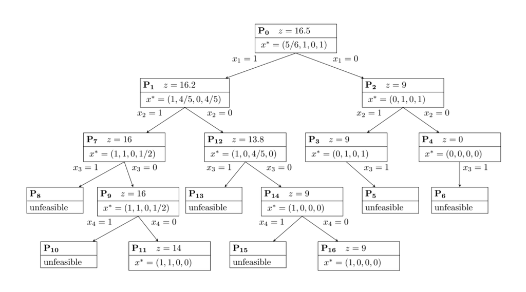

Suppose that the Branch and Bound (BB) algorithm applies to this problem. Also, let’s suppose that the algorithm visits the sub-problems in the following order P0 , P1 , . . . , P16. Clearly, the algorithm does not visit all nodes.

1. Determine the nodes that will be visited by the BB algorithm and for each of them get the upper and lower limit deduced by the algorithm in the execution.

$$\begin{array}{lll}
\text { Node } & \text { Upper limit } & \text { Lower limit } \\
P1 & \text 16 & \text 0 \\
P2 & \text 16 & \text 9 \\
P7 & \text 16 & \text 9 \\
P8 & \text Unfeasible \\
P9 & \text 16 & \text 9 \\
P10 & \text Unfeasible \\
P11 & \text 16 & \text 14 \\
P12 & \text 14 & \text 14 \\
\end{array}$$

2. Solve the problem with an ILP solver and check the value of the objective function matches the one found at point 1.

Building the model

```r
library(lpSolveAPI)
lp.model <- make.lp(0, 4) # create model with 0 constraints and 4 variables
name.lp(lp.model, "task2") # name the model
lp.control(lp.model, sense="max")
```

[output not shown]

[output cut: 12 more lines]

[output not shown]

```r
set.objfn(lp.model, c(9, 5, 6, 4))
```

Defining the constraints

```r
add.constraint(lp.model, c(6, 3, 5, 2), "<=", 10 )
add.constraint(lp.model, c(0, 0, 1, 1), "<=", 1 )
add.constraint(lp.model, c(-1, 0, 1, 0), "<=", 0 )
add.constraint(lp.model, c(0, -1, 0, 1), "<=", 0 )
set.type(lp.model, c(1, 2, 3, 4), "binary")
solve(lp.model)
```

```
## [1] 0
```

Solving and viewing results

```r
sprintf("The optimal combination of variables is:")
```

```
## [1] "The optimal combination of variables is:"
```

```r
get.variables(lp.model)
```

```
## [1] 1 1 0 0
```

```r
sprintf("This combination achieves an objective function score of: %i", get.objective(lp.model))
```

```
## [1] "This combination achieves an objective function score of: 14"
```